# R Plotting and Aesthetics.

Brady Johnston

26/08/2019

# Plotting Biological Data with R

Hopefully from this tutorial you’ll be a bit more comfortable interacting with R, and be able to make simple plots from some biological data.

To begin with, create a new R script and save it in the tutorial directory.

## Importing you data.

To start working we need to import our data. It is in a .csv file in 3 columns: protein concentration and duplicate observations of the absorbance.

To read it in, we use the command `read.csv()` supplying it with a string that is the path to the file.

```r
data <- read.csv("./abs.csv")
print(data)
```

```
##    prot  abs1   ab2
## 1 0.000 0.329 0.327
## 2 0.016 0.352 0.341
## 3 0.031 0.349 0.355
## 4 0.063 0.379 0.383
## 5 0.125 0.417 0.417
## 6 0.250 0.491 0.446
## 7 0.500 0.668 0.655
## 8 1.000 0.956 0.905
```

## Machine-readable data

While this is how we would normally table our data collection, in reality we’re cutting corners. Machines don’t like cutting corners and it’s better to have data in a ‘long’ format where each observation (absorbance measurement) has its own concentration associated with it.

```r
data[,1:2]
```

```
##    prot  abs1
## 1 0.000 0.329
## 2 0.016 0.352
## 3 0.031 0.349
## 4 0.063 0.379
## 5 0.125 0.417
## 6 0.250 0.491
## 7 0.500 0.668
## 8 1.000 0.956
```

```r
abs1 <- data[,1:2]
colnames(abs1) <- c("prot", "abs")
abs2 <- data[,c(1,3)]
colnames(abs2) <- c("prot", "abs")
combined <- abs1
combined <- rbind(combined,abs2)
combined
```

```
##     prot   abs
## 1  0.000 0.329
## 2  0.016 0.352
## 3  0.031 0.349
## 4  0.063 0.379
## 5  0.125 0.417
## 6  0.250 0.491
## 7  0.500 0.668
## 8  1.000 0.956
## 9  0.000 0.327
## 10 0.016 0.341
## 11 0.031 0.355
## 12 0.063 0.383
## 13 0.125 0.417
## 14 0.250 0.446
## 15 0.500 0.655
## 16 1.000 0.905
```

## Why though?

While it seems like it was a lot of work for nothing (you probably could have done this in excel in less time), when you start dealing with considerably larger dadta sets it starts coming in handy. Also if you set it up properly in excel then you can automate it later using scripts.

## Time to start plotting some data.

A simple plot is easy enough.

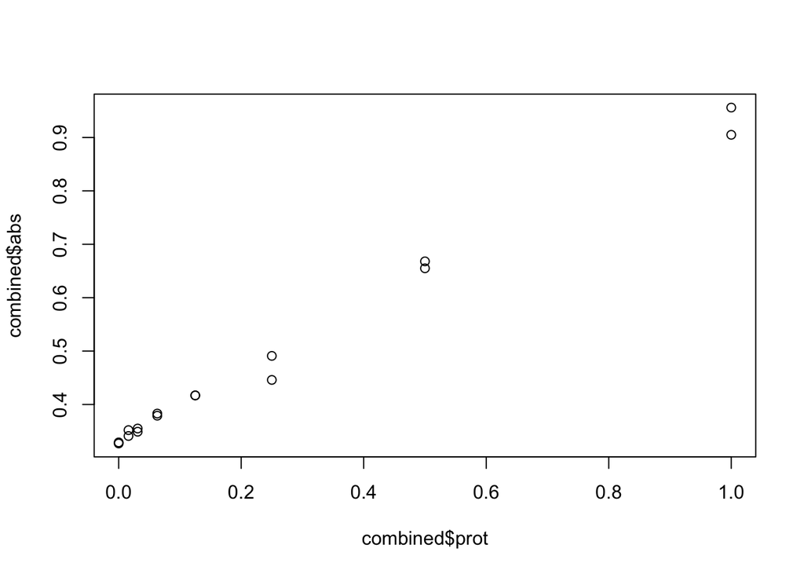

```r
plot(combined$prot, combined$abs)
```

This tutorial is after all about *aesthetics* so we’re going to be using a package called `ggplot2`.

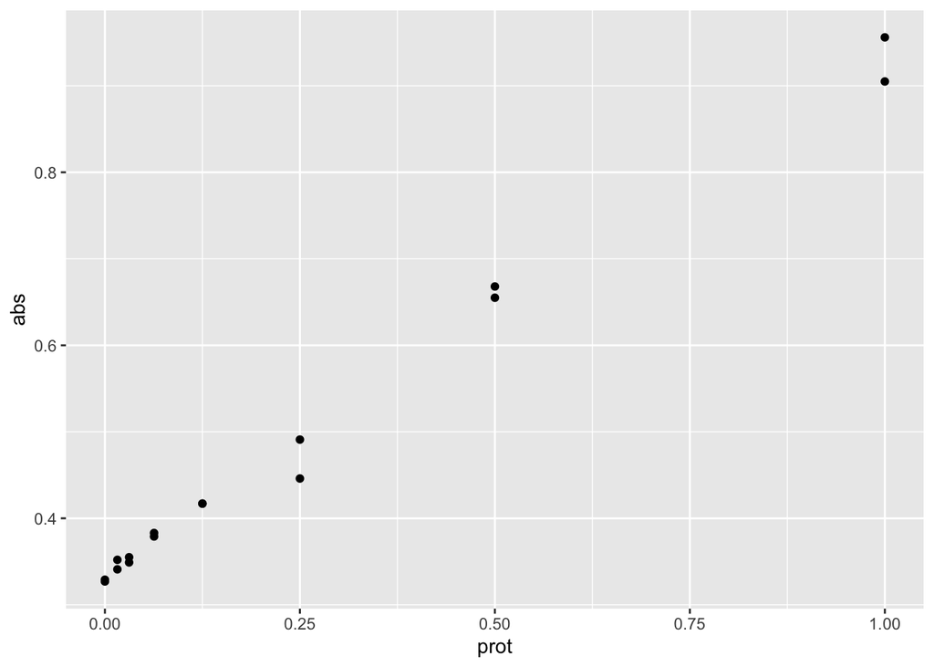

```r
library(ggplot2)
#ggplot(dataframe, aes(x data, y data)) + plottype
plt <- ggplot(combined, aes(prot, abs)) + geom_point()
plt
```

Now that’s looking a bit nicer. We want to plot a line of best fit, get the equation and plot our unknows.

```r
line <- lm(combined$abs~combined$prot)
summary(line)
```

```
##
## Call:
## lm(formula = combined$abs ~ combined$prot)
##
## Residuals:
##       Min        1Q    Median        3Q       Max
## -0.040756 -0.006025  0.004625  0.007011  0.030494
##
## Coefficients:
##               Estimate Std. Error t value Pr(>|t|)
## (Intercept)   0.336005   0.005801   57.92  < 2e-16 ***
## combined$prot 0.603002   0.014211   42.43 3.42e-16 ***
## ---
## Signif. codes:  0 '***' 0.001 '**' 0.01 '*' 0.05 '.' 0.1 ' ' 1
##
## Residual standard error: 0.01843 on 14 degrees of freedom
## Multiple R-squared:  0.9923, Adjusted R-squared:  0.9917
## F-statistic:  1801 on 1 and 14 DF,  p-value: 3.421e-16
```

Get the details that you require from the linear model (intercept, slope).

```r
int <- summary(line)$coefficients[1]
slope <- summary(line)$coefficients[2]
```

With this linear model information, we can calculate our unknowns.

```r
rsquare <- round(summary(line)$r.squared, digits = 3)

abs.unks <- c(0.544, 0.568, 0.705)
prot.unks <- (abs.unks - int) / slope

calcdata <- as.data.frame(abs.unks)
prot.unks
```

```
## [1] 0.3449324 0.3847333 0.6119300
```

```r
calcdata$prot <- round(prot.unks, digits = 3)
calcdata
```

```
##   abs.unks  prot
## 1    0.544 0.345
## 2    0.568 0.385
## 3    0.705 0.612
```

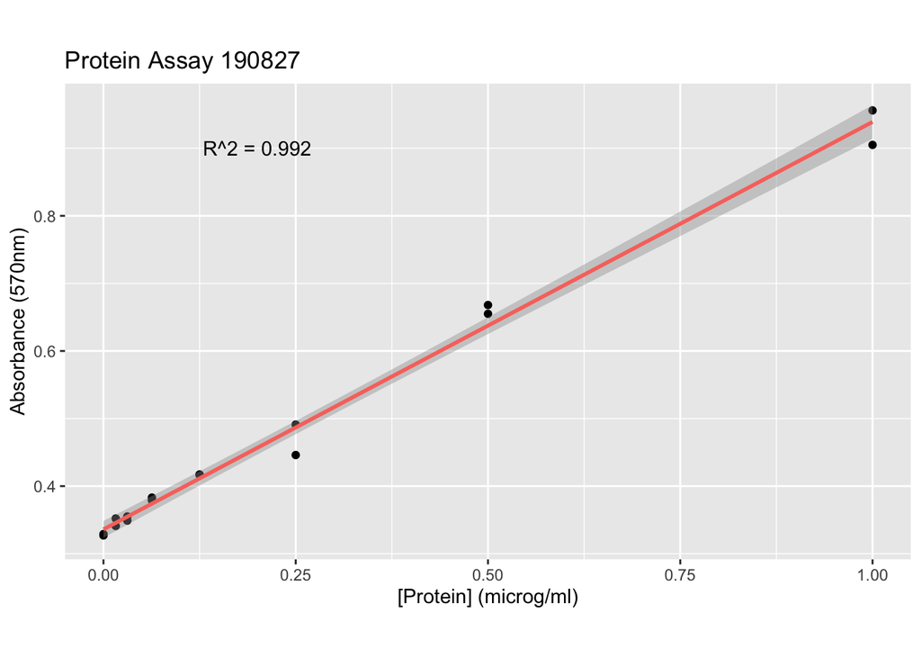

```r
p <- ggplot(combined,          # specify the data frame with data
        aes(prot,abs)) +   # specify the x and y for the graph
        geom_point() +          # make a scatter plot
        stat_smooth(method = "lm", aes(colour = "red")) +  # add a linear model line
        xlab("[Protein] (microg/ml)") +   # label x-axis
        ylab("Absorbance (570nm)") +    # label y-axis
        ggtitle("Protein Assay 190827") + # Add a title
        theme(legend.position = "", aspect.ratio = 9/16) + # remove unnecessary legend
        annotate("text", 0.2,0.9, label = paste("R^2 =",rsquare)) #annotate with R^2 value
  p
```

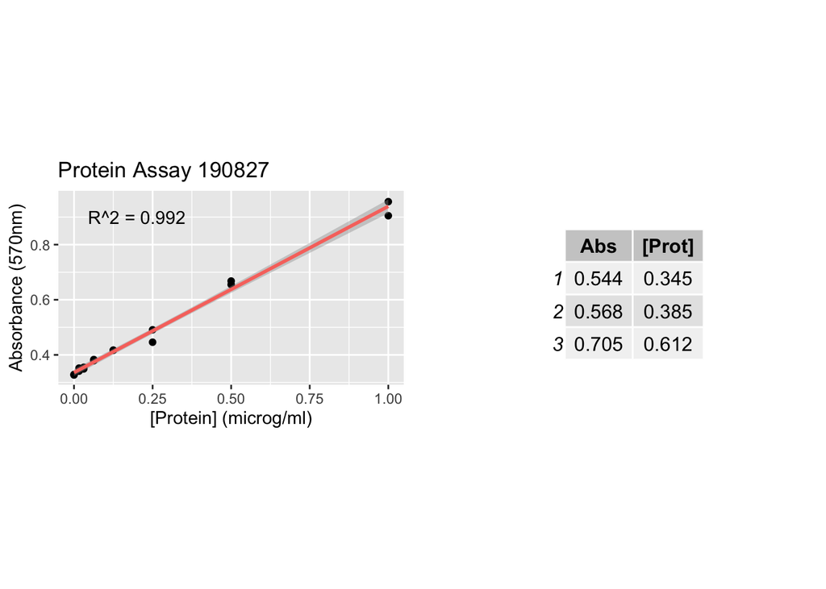

```r
library("gridExtra")
library("grid")
colnames(calcdata) <- c("Abs", "[Prot]")
t1<-tableGrob(calcdata)
rm(calcdata)
grid.arrange(p,t1, nrow=1)
```

# Bringing it together

All of the previous can be summarised in a script that looks like the following. Copy and paste this script into a new R document, change the ./abs.csv to another file and edit the abs.unks to `c(0.44,0.53,0.68)` then just run the scipt. Now you have a script that will analyse your data and produce great graphics in a matter of seconds.

You can even make this executable from the command line and take inputs, but that’s for another tutorial.

```r
library("gridExtra")
library("grid")
library("ggplot2")

data <- read.csv("./abs.csv")

abs1 <- data[,1:2]
colnames(abs1) <- c("prot", "abs")
abs2 <- data[,c(1,3)]
colnames(abs2) <- c("prot", "abs")
combined <- abs1
combined <- rbind(combined,abs2)

line <- lm(combined$abs~combined$prot)

int <- summary(line)$coefficients[1]
slope <- summary(line)$coefficients[2]
rsquare <- round(summary(line)$r.squared, digits = 3)

abs.unks <- c(0.544, 0.568, 0.705)
prot.unks <- (abs.unks - int) / slope

calcdata <- as.data.frame(abs.unks)
calcdata$prot <- round(prot.unks, digits = 3)

p <- ggplot(combined,          # specify the data frame with data
        aes(prot,abs)) +   # specify the x and y for the graph
        geom_point() +          # make a scatter plot
        stat_smooth(method = "lm", aes(colour = "red")) +  # add a linear model line
        xlab("[Protein] (microg/ml)") +   # label x-axis
        ylab("Absorbance (570nm)") +    # label y-axis
        ggtitle("Protein Assay 190827") + # Add a title
        theme(legend.position = "", aspect.ratio = 9/16) + # remove unnecessary legend
        annotate("text", 0.2,0.9, label = paste("R^2 =",rsquare)) #annotate with R^2 value


colnames(calcdata) <- c("Abs", "[Prot]")
t1<-tableGrob(calcdata)
rm(calcdata)
grid.arrange(p,t1, nrow=1)
```